# Individual Taxis

### NYC Taxi Analysis

#### Summer 2015

Here I’ll analyze the taxi data based on a random sampling of drivers, rather than a random sampling of trips. This new data set will give us a random 3% of NYC cab drivers (967 drivers) and all of their trip data from January 2013.

Let’s look at a few different metrics, starting with the total revenue per cab.

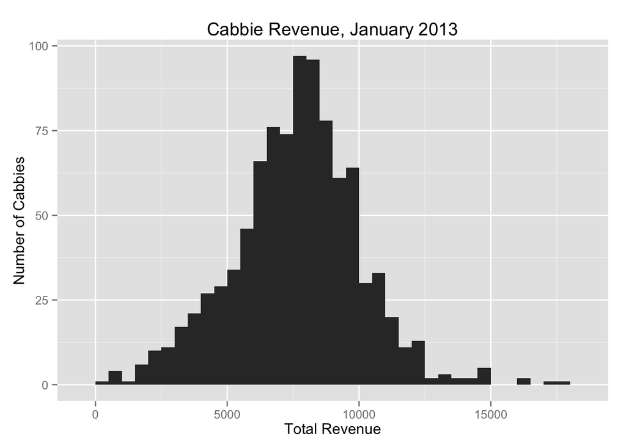

```r
taxi_indiv_rev <- taxi_indiv %>%
  group_by(hack_license) %>%
  summarize(total_revenue = sum(total_revenue)) %>%
  arrange(desc(total_revenue))

ggplot(taxi_indiv_rev, aes(x = total_revenue)) + geom_histogram(binwidth= 500) +
  xlab("Total Revenue") + ylab("Number of Cabbies") +
  ggtitle("Cabbie Revenue, January 2013")
```

How about total number of passengers and total number of trips?

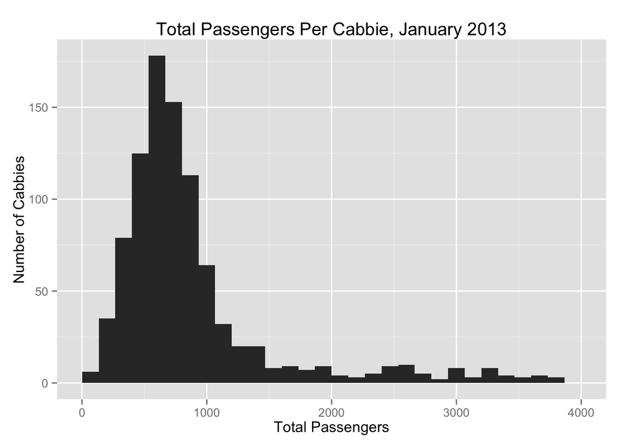

```r
taxi_indiv_pass <- taxi_indiv %>%
  group_by(hack_license) %>%
  summarize(num_passengers = sum(total_num_passengers), num_trips = sum(total_trips))

ggplot(taxi_indiv_pass) + geom_histogram(aes(num_passengers)) + xlim(0,4000) +
  xlab("Total Passengers") + ylab("Number of Cabbies") +
  ggtitle("Total Passengers Per Cabbie, January 2013")
```

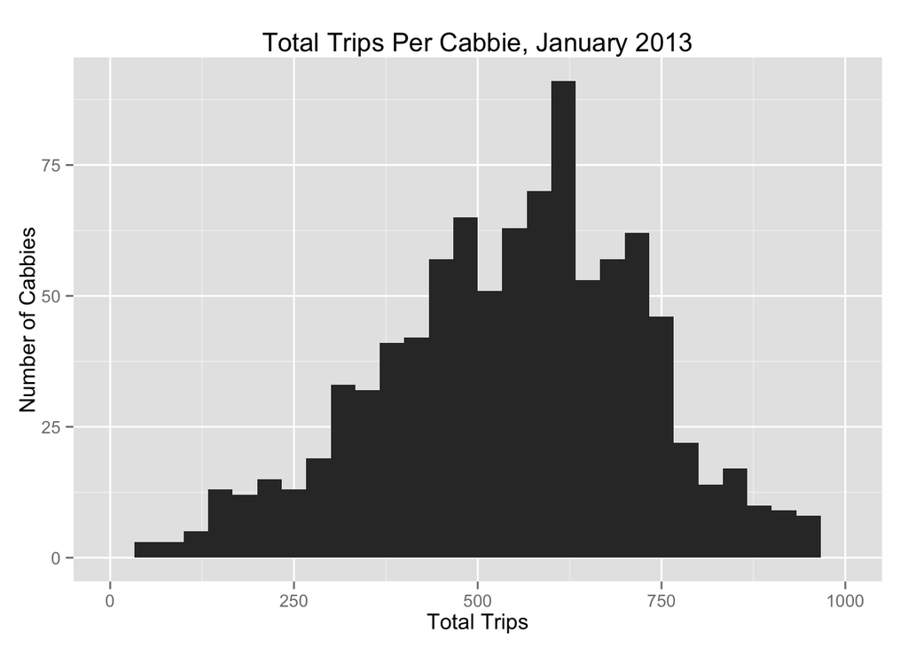

```r
ggplot(taxi_indiv_pass) + geom_histogram(aes(num_trips)) + xlim(0,1000) +
  xlab("Total Trips") + ylab("Number of Cabbies") +
  ggtitle("Total Trips Per Cabbie, January 2013")
```

What’s the average overall tip rate for a cabbie? Note that this data set only includes trips paid for using a card. This data set lacks tip information for trips paid in cash. We can see that most cabbies are tipped on average 13-16%.

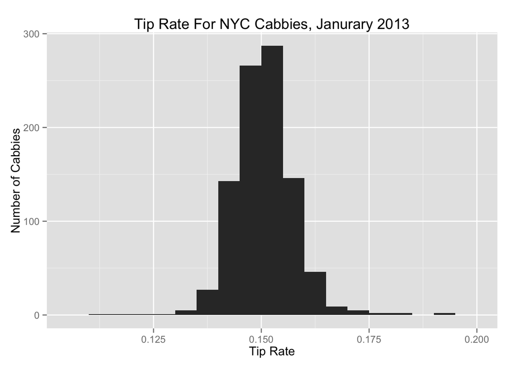

```r
taxi_indiv_tips <- taxi_indiv %>%
  dplyr::filter(payment_type == "CRD") %>%
  group_by(hack_license) %>%
  summarize(total_revenue = sum(total_revenue), total_tips = sum(total_tips)) %>%
  mutate(tip_rate = total_tips/total_revenue)

ggplot(taxi_indiv_tips, aes(tip_rate)) + geom_histogram(binwidth = .005) +
  xlab("Tip Rate") + ylab("Number of Cabbies") +
  ggtitle("Tip Rate For NYC Cabbies, Janurary 2013")
```

Number of days worked in the month:

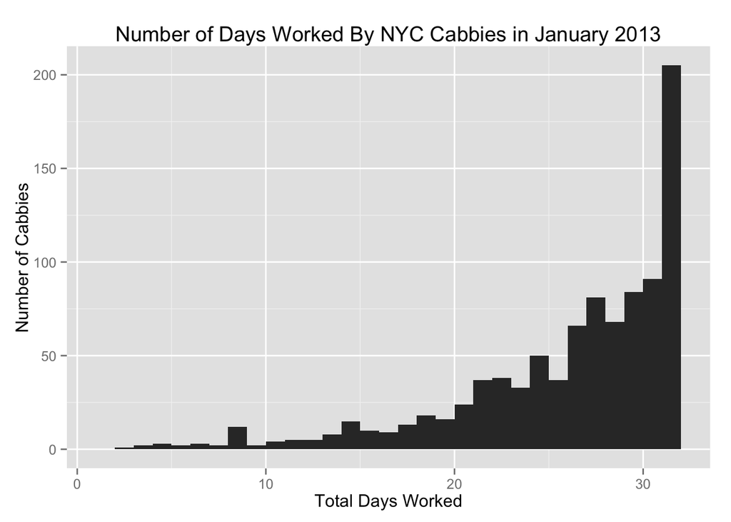

```r
taxi_indiv_days <- taxi_indiv %>%
  group_by(hack_license) %>%
  summarize(total_days_worked = n_distinct(pickup_date)) %>%
  arrange(desc(total_days_worked))

ggplot(taxi_indiv_days, aes(total_days_worked)) + geom_histogram(binwidth = 1) +
  xlab("Total Days Worked") + ylab("Number of Cabbies") +
  ggtitle("Number of Days Worked By NYC Cabbies in January 2013")
```

Wow. Looks like many of our cabbies worked every single day of January. That’s dedication!

Let’s compute the total number of hours each cabbie spends in service (not necessarily on the meter).

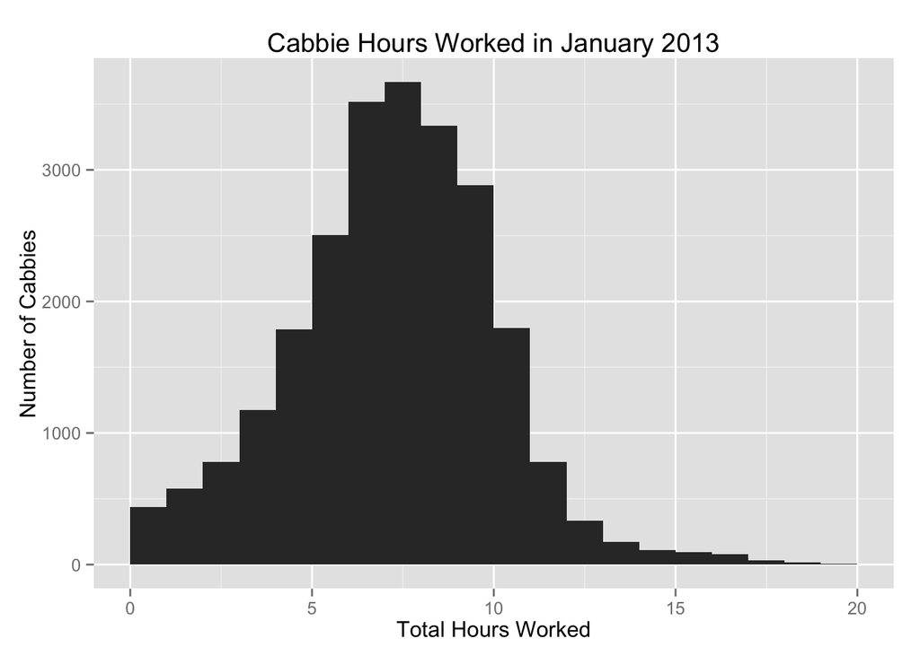

```r
trip_times <- taxi_strat %>%
  group_by(hack_license, pickup_date) %>%
  summarize(secs_on_meter = sum(trip_time_in_secs), total_amount = sum(total_amount))

taxi_empty <- taxi_strat %>%
  select(hack_license, pickup_date, pickup_datetime, dropoff_datetime) %>%
  arrange(hack_license, pickup_date, pickup_datetime)
# not using mutate here because my version of dplyr has a bug with mutate and lubridate
taxi_empty$empty_time <- as.integer(taxi_empty$pickup_datetime - lag(taxi_empty$dropoff_datetime))

taxi_empty <- taxi_empty %>%
  mutate(empty_time = ifelse(is.na(empty_time)|empty_time<0|empty_time>3600,0,empty_time)) %>%
  group_by(hack_license, pickup_date) %>%
  summarize(total_empty_time = sum(empty_time)) %>%
  left_join(trip_times, by = c("hack_license" = "hack_license",
                               "pickup_date" = "pickup_date")) %>%
  mutate(total_hours = (total_empty_time + secs_on_meter)/3600)

ggplot(data = taxi_empty, aes(x = total_hours)) + geom_histogram(binwidth = 1) +
  xlim(0,20) + xlab("Total Hours Worked") + ylab("Number of Cabbies") +
  ggtitle("Cabbie Hours Worked in January 2013")
```

```r
summary(taxi_empty$total_hours)
```

```
##    Min. 1st Qu.  Median    Mean 3rd Qu.    Max.
##   0.000   5.550   7.333   7.253   9.083  21.340
```

Let’s look at efficiency from this point of view.

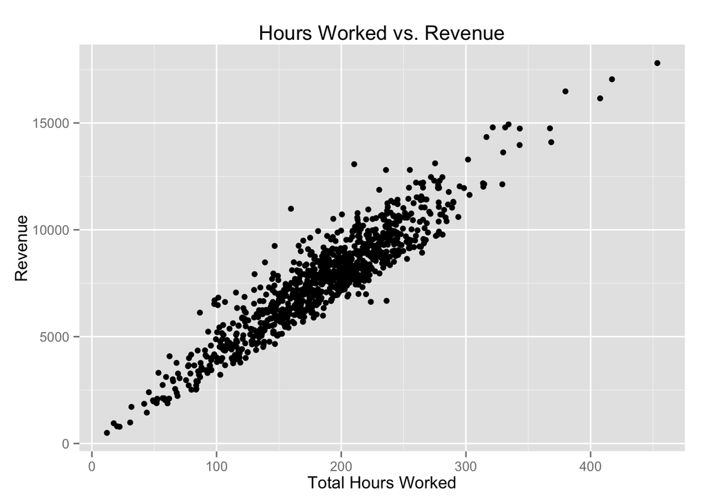

```r
taxi_empty_month <- taxi_empty %>%
  group_by(hack_license) %>%
  summarize(total_empty_time = sum(total_empty_time), secs_on_meter = sum(secs_on_meter),
            revenue = sum(total_amount), total_hours = sum(total_hours))
ggplot(data = taxi_empty_month, aes(x = total_hours, y = revenue)) + geom_point() +
  xlab("Total Hours Worked") + ylab("Revenue") + ggtitle("Hours Worked vs. Revenue")
```

```r
fit <- lm(revenue ~ total_hours, data = taxi_empty_month)
summary(fit)
```

```
##
## Call:
## lm(formula = revenue ~ total_hours, data = taxi_empty_month)
##
## Residuals:
##     Min      1Q  Median      3Q     Max
## -2957.0  -608.0  -106.5   508.0  4447.7
##
## Coefficients:
##             Estimate Std. Error t value Pr(>|t|)
## (Intercept)  447.506     95.430   4.689 3.14e-06 ***
## total_hours   38.867      0.492  79.005  < 2e-16 ***
## ---
## Signif. codes:  0 '***' 0.001 '**' 0.01 '*' 0.05 '.' 0.1 ' ' 1
##
## Residual standard error: 876.5 on 942 degrees of freedom
## Multiple R-squared:  0.8689, Adjusted R-squared:  0.8687
## F-statistic:  6242 on 1 and 942 DF,  p-value: < 2.2e-16
```

As expected, we find a strong linear correlation between the total hours worked and revenue.

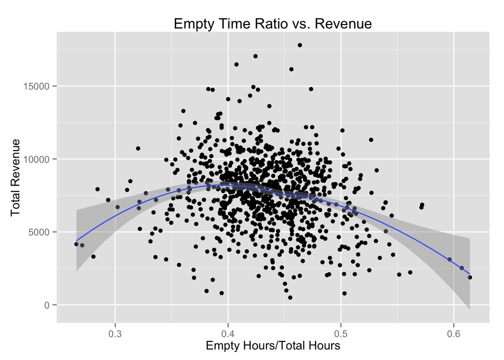

```r
ggplot(taxi_empty_month, aes(x = (total_empty_time/3600)/total_hours, y = revenue)) +
  geom_point() + geom_smooth() + xlab("Empty Hours/Total Hours") + ylab("Total Revenue") +
  ggtitle("Empty Time Ratio vs. Revenue")
```

Are there certain drivers that have only cash/only card payments? Maybe some drive cars without card capabilities.

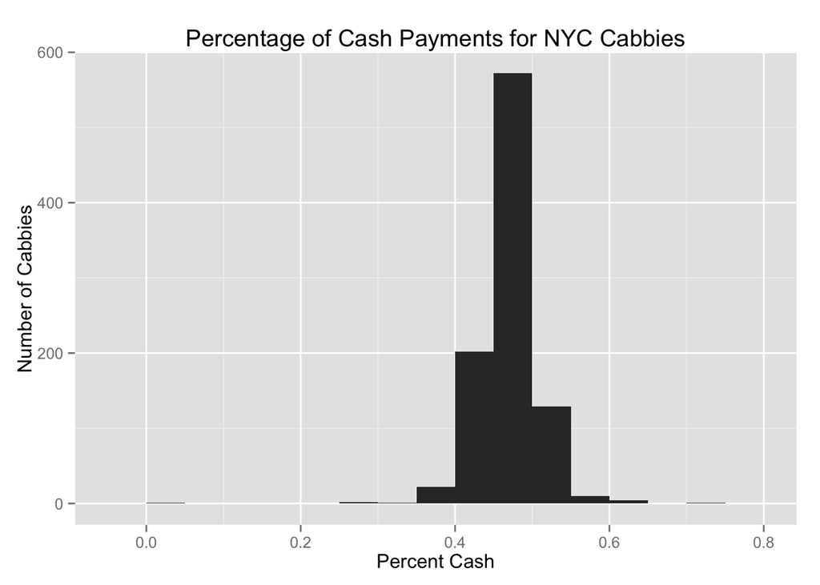

```r
taxi_indiv_payment <- taxi_indiv %>%
  group_by(hack_license, payment_type) %>%
  summarize(count = n()) %>%
  spread(payment_type, count, fill = 0) %>%
  mutate(total = CRD + CSH + DIS + NOC + UNK) %>%
  mutate(CRD = CRD/total, CSH = CSH/total, DIS = DIS/total, NOC = NOC/total, UNK = UNK/total) %>%
  arrange(desc(CSH)) %>%
  dplyr::filter(total>=10)

ggplot(data = taxi_indiv_payment, aes (x = CSH)) + geom_histogram(binwidth = .05) +
  xlab("Percent Cash") + ylab("Number of Cabbies") +
  ggtitle("Percentage of Cash Payments for NYC Cabbies")
```

Let’s look at cabbies’ driving schedules. We can use NMF (nonlinear matrix factorization) to find relationships between different pickup hours of trips. In order to tidy our data set, we modify taxi_indiv to be a matrix with individual drivers as rows and pickup hours as columns. A “1” in any given column corresponds to 6 or more pickups by that driver in that hour, whie a “0” indicates fewer than 6 pickups at that hour in January 2013.

```r
taxi_indiv_nmf <- taxi_indiv %>%
  group_by(hack_license, pickup_hour) %>%
  summarize(count = n()) %>%
  mutate(count = ifelse(count>5,1,0)) %>%
  dplyr::filter(!is.na(count), !is.na(hack_license), !is.na(pickup_hour)) %>%
  spread(pickup_hour, count, fill = 0)
taxi_indiv_nmf$total <- rowSums(taxi_indiv_nmf[,2:25])
taxi_indiv_nmf <- taxi_indiv_nmf %>%
  dplyr::filter(total>0) %>%
  dplyr::select(-hack_license,-total)

nmf_taxi <- nmf(as.matrix(taxi_indiv_nmf), rank = 2)
```

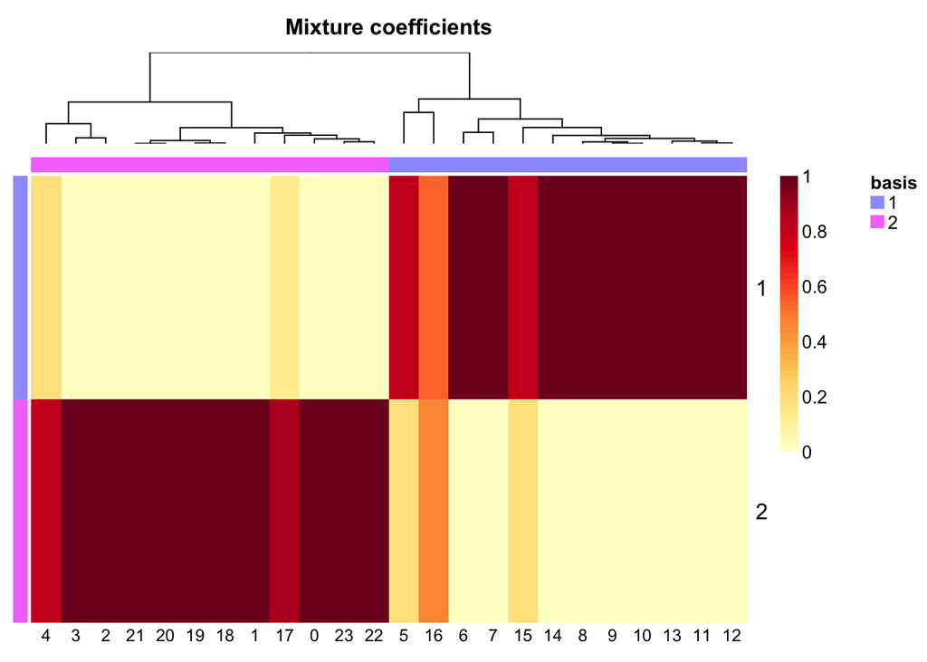

In this basis map, the rows are the cabbies and the columns are our two shift groups. We can see that most cabbies fall distinctly into one of the two groups, meaning they primarily work either the morning or night shift. However, there is also a group that seems pretty split, implying that several cabbies in our sample work a mix of morning and night shifts.

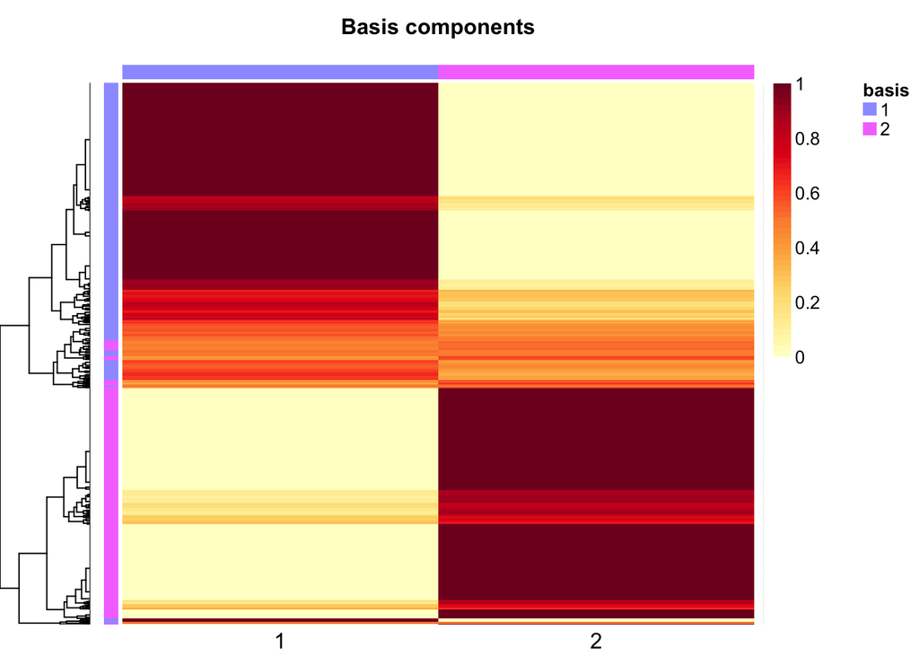